# Plot Cointegration Combinations

Kevin Lu

December 18, 2017

# 1. Load Packages

```r
source("./src/util/01-load-packages.R")
```

# 2. Load Data

An initial run of 18,600 iterations was completed using the following search parameters:

```r
# time_resolution <- sample(c(300, 900, 1800, 7200, 14400, 86400), size = 1)
# start_date <- sample(seq(from = ymd("2017-01-01"), to = ymd("2017-10-01"), by = "1 day"), size = 1)
# end_date <- sample(seq(from = start_date + 3, to = Sys.Date(), by = "1 day"), size = 1)
results_a <- read_csv("./output/tuning/search-cointegration-results-a.csv")
```

A secondary run of 18,600 iterations was completed using the following search parameters:

```r
# time_resolution <- sample(c(300, 900, 1800, 7200, 14400, 86400), size = 1)
# start_date <- sample(seq(from = ymd("2017-01-01"), to = ymd("2017-10-01"), by = "1 day"), size = 1)
# end_date <- sample(seq(from = start_date + 3, to = start_date + 50, by = "1 day"), size = 1)
results_b <- read_csv("./output/tuning/search-cointegration-results-b.csv")
```

# 3. Summary Plots

The following plots show the distribution of the average ADF test statistic of the 98 coin pairs of interest faceted by time resolution. The critical value at the 1 percent value to reject the null of a unit root is around -3.50 depending on the size of the population. A time resolution of 5-minute observations (300 seconds) has the most number of observations where the average ADF test statistic is significant at the 1 percent level.

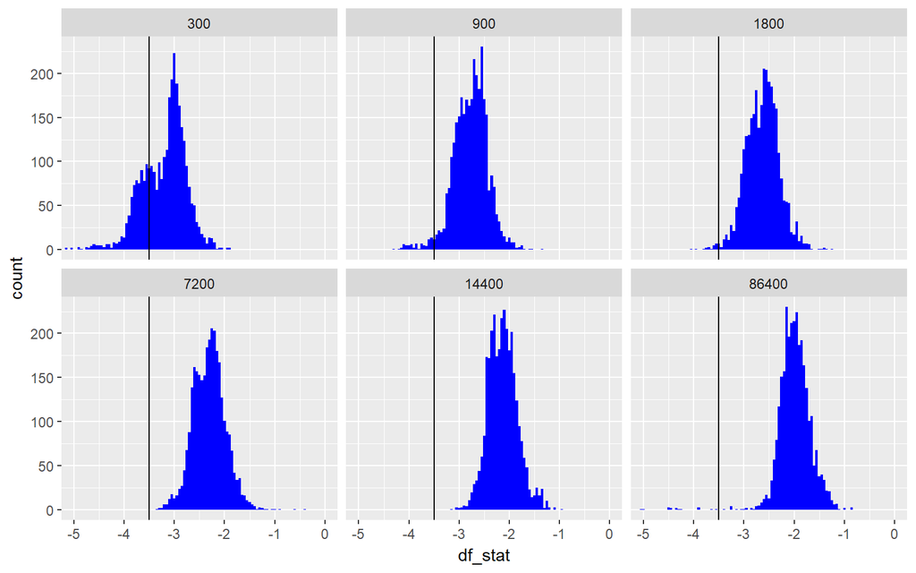

```r
ggplot(results_a, aes(x = df_stat)) +
  geom_histogram(binwidth = 0.05, fill = "blue") +
  coord_cartesian(xlim = c(-5, 0)) +
  geom_vline(xintercept = -3.50) +
  facet_wrap(~ time_resolution)
```

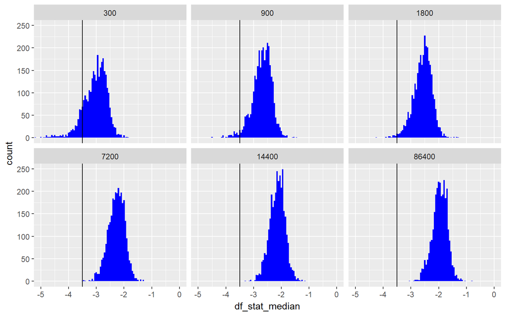

```r
ggplot(results_b, aes(x = df_stat_median)) +
  geom_histogram(binwidth = 0.05, fill = "blue") +
  coord_cartesian(xlim = c(-5, 0)) +
  geom_vline(xintercept = -3.50) +
  facet_wrap(~ time_resolution)
```

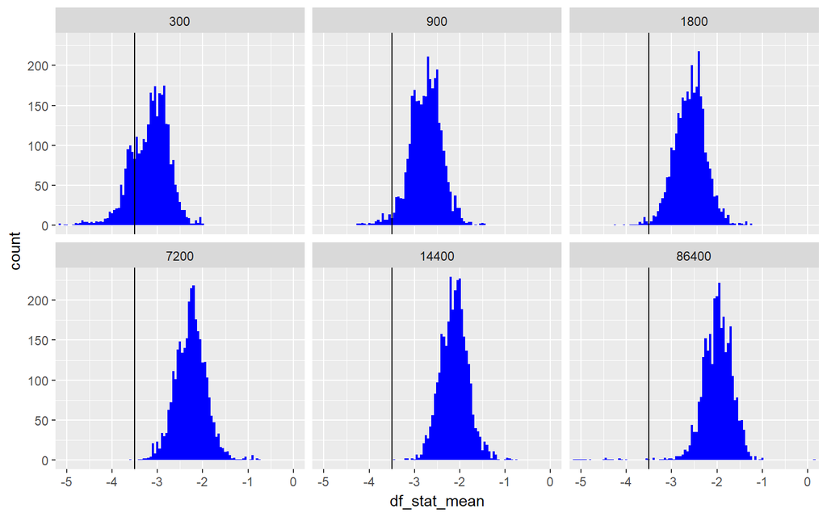

```r
ggplot(results_b, aes(x = df_stat_mean)) +
  geom_histogram(binwidth = 0.05, fill = "blue") +
  coord_cartesian(xlim = c(-5, 0)) +
  geom_vline(xintercept = -3.50) +
  facet_wrap(~ time_resolution)
```

The following plots show the distribution of the start_date faceted by time resolution. Good sampling of different start dates across time resolution.

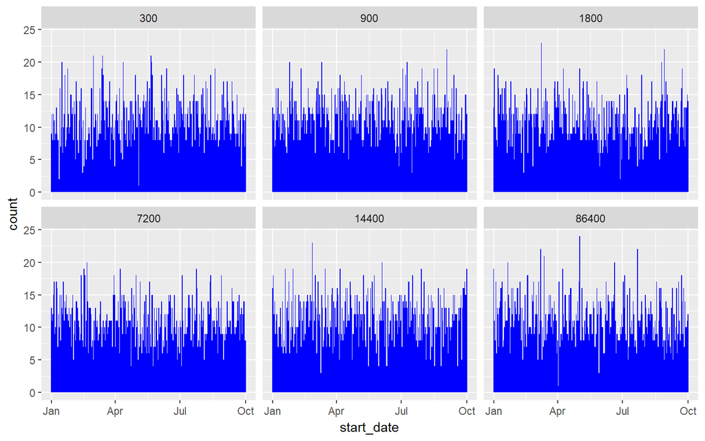

```r
ggplot(results_a, aes(x = start_date)) +
  geom_histogram(binwidth = 1, fill = "blue") +
  facet_wrap(~ time_resolution)
```

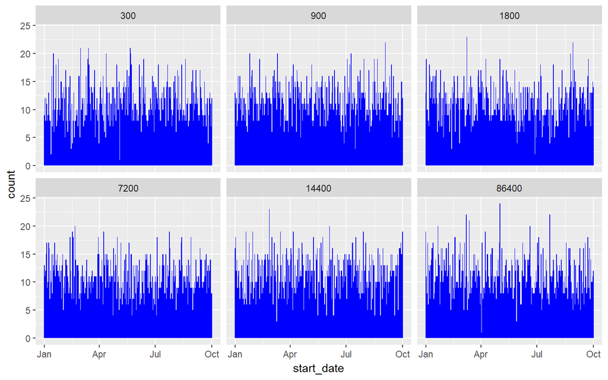

```r
ggplot(results_b, aes(x = start_date)) +
  geom_histogram(binwidth = 1, fill = "blue") +
  facet_wrap(~ time_resolution)
```

The following plots show the distribution of the end_date faceted by time resolution. Good sampling of different end dates across time resolution.

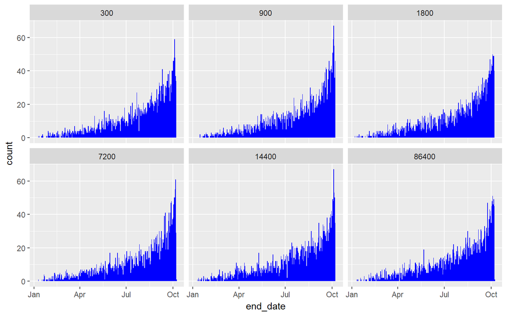

```r
ggplot(results_a, aes(x = end_date)) +
  geom_histogram(binwidth = 1, fill = "blue") +
  facet_wrap(~ time_resolution)
```

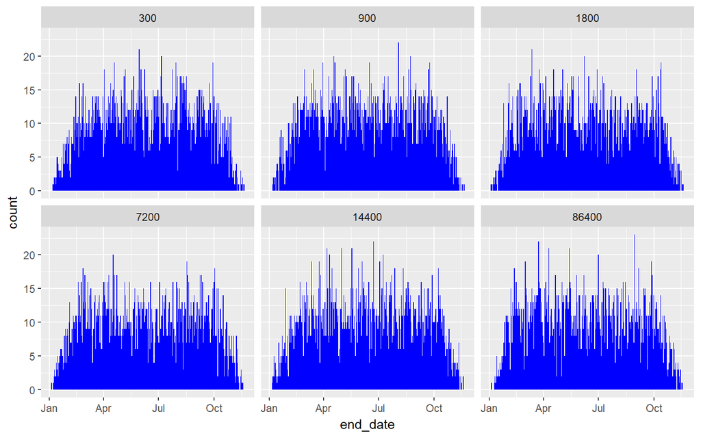

```r
ggplot(results_b, aes(x = end_date)) +
  geom_histogram(binwidth = 1, fill = "blue") +
  facet_wrap(~ time_resolution)
```

The following plot show the distribution of the length of the window in days. Good sampling of length across time resolution.

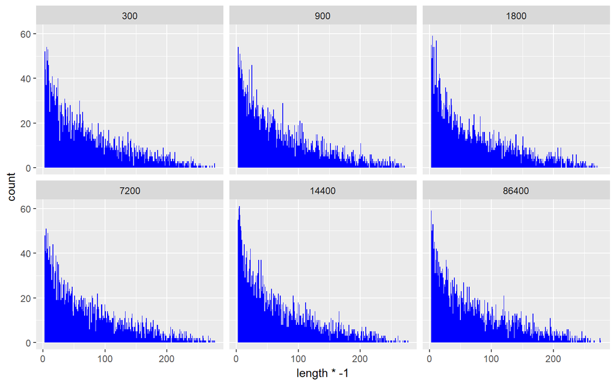

```r
ggplot(results_a, aes(x = length * -1)) +
  geom_histogram(binwidth = 1, fill = "blue") +
  facet_wrap(~ time_resolution)
```

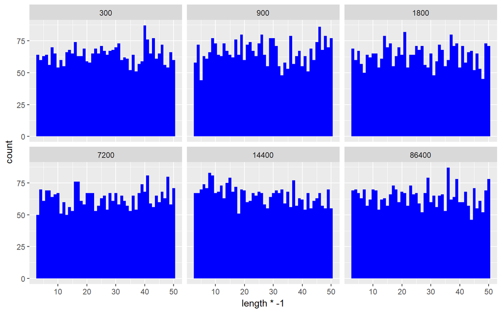

```r
ggplot(results_b, aes(x = length * -1)) +
  geom_histogram(binwidth = 1, fill = "blue") +
  facet_wrap(~ time_resolution)
```

# 4. Explore Optimal Combination

The following plots show the distribution of the average ADF test statistic across time resolution. A time resolution of 5-minute observations (300 seconds) has the lowest average of the average ADF statistic although there are some very negative outliers at the 1-day time resolution.

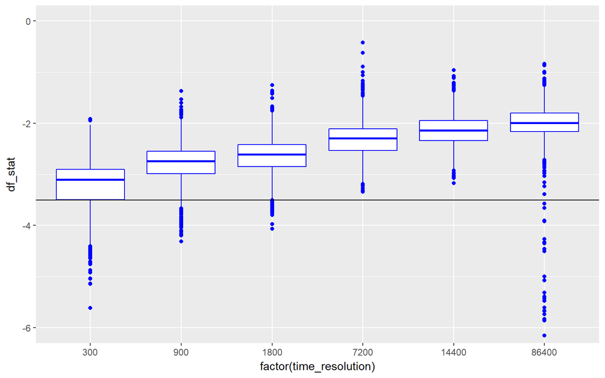

```r
ggplot(results_a, aes(x = factor(time_resolution))) +
  geom_boxplot(aes(y = df_stat), colour = "blue") +
  geom_hline(yintercept = -3.50) +
  coord_cartesian(ylim = c(-6, 0))
```

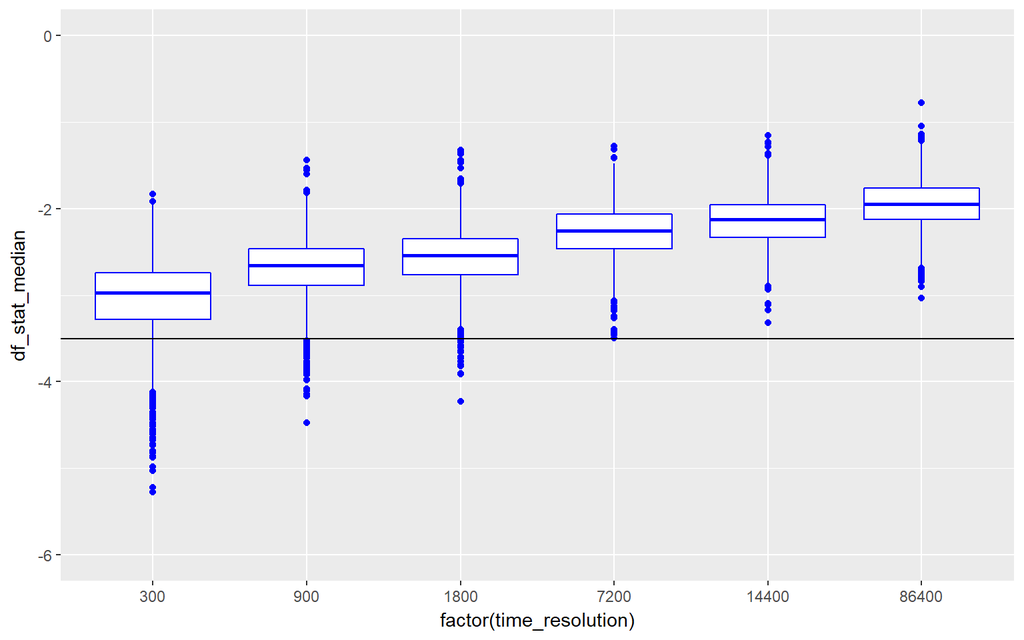

```r
ggplot(results_b, aes(x = factor(time_resolution))) +
  geom_boxplot(aes(y = df_stat_median), colour = "blue") +
  geom_hline(yintercept = -3.50) +
  coord_cartesian(ylim = c(-6, 0))
```

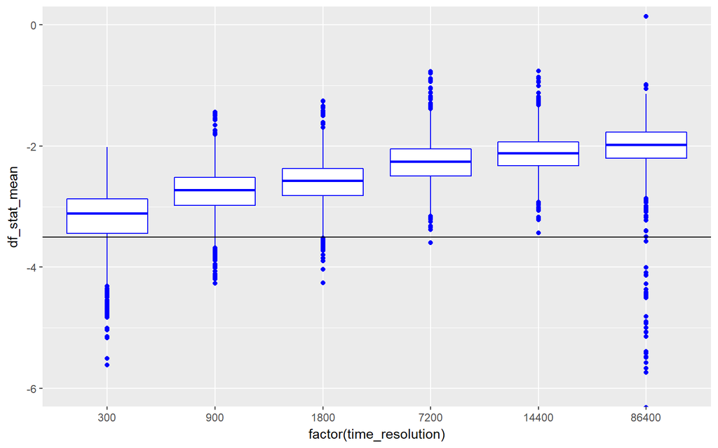

```r
ggplot(results_b, aes(x = factor(time_resolution))) +
  geom_boxplot(aes(y = df_stat_mean), colour = "blue") +
  geom_hline(yintercept = -3.50) +
  coord_cartesian(ylim = c(-6, 0))
```

The folliowing plots show the individual average ADF test statistics by length of window faceted by time resolution. Shorter window lengths are associated with more negative ADF test statistics.

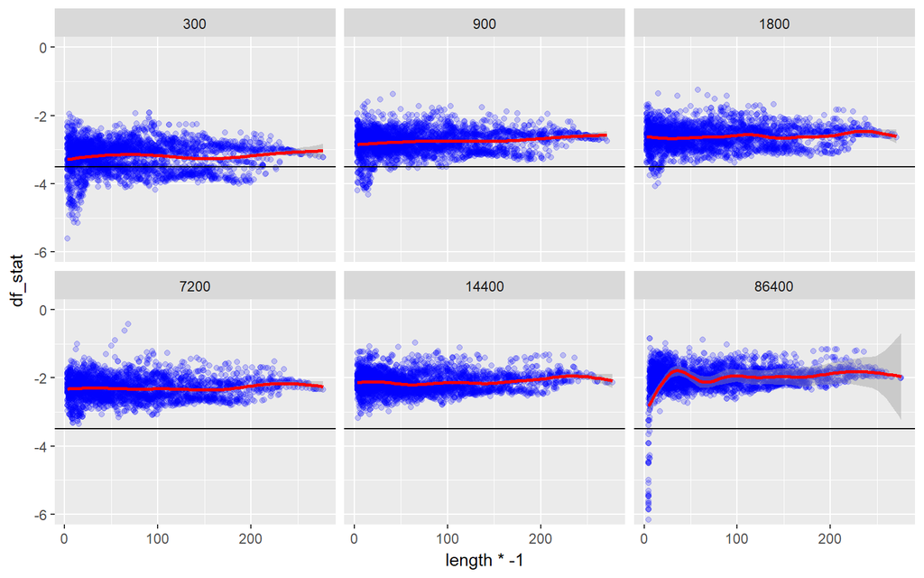

```r
ggplot(results_a, aes(x = length * -1)) +
  geom_point(aes(y = df_stat), colour = "blue", alpha = 0.2) +
  geom_hline(yintercept = -3.50) +
  coord_cartesian(ylim = c(-6, 0)) +
  geom_smooth(aes(y = df_stat), colour = "red") +
  facet_wrap(~ time_resolution)
```

This plot is identical to above but focuses on a window length of 0 to 50 days. The conclusion is that a time resolution of 5-minute observations (300 seconds) along with a window length of between 5 to 20 days exhibits the most mean reversion out of the combinations studied.

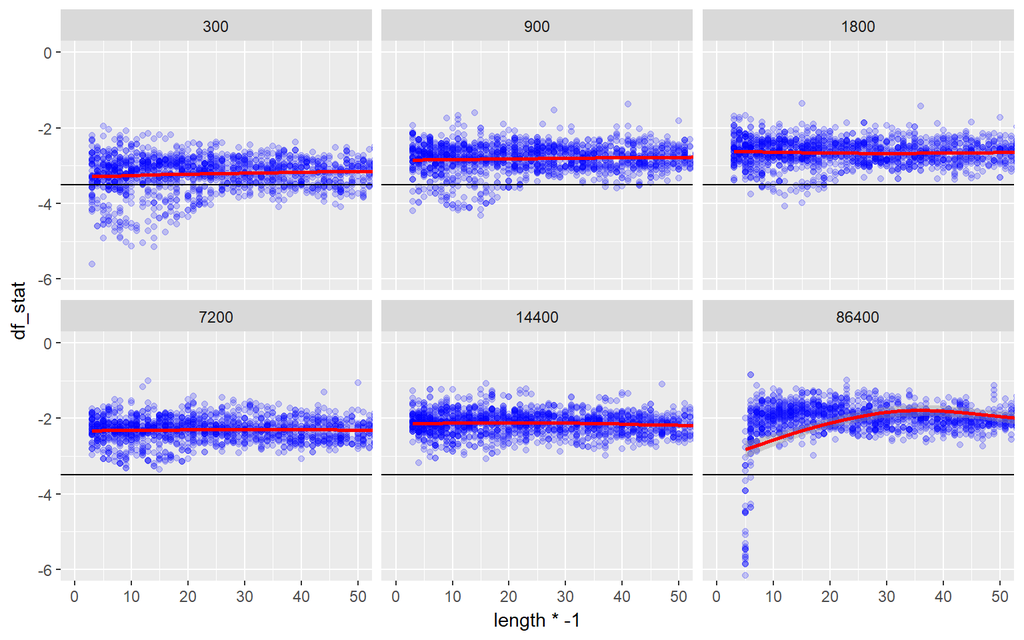

```r
ggplot(results_a, aes(x = length * -1)) +
  geom_point(aes(y = df_stat), colour = "blue", alpha = 0.2) +
  geom_hline(yintercept = -3.50) +
  coord_cartesian(ylim = c(-6, 0), xlim = c(0, 50)) +
  geom_smooth(aes(y = df_stat), colour = "red") +
  facet_wrap(~ time_resolution)
```

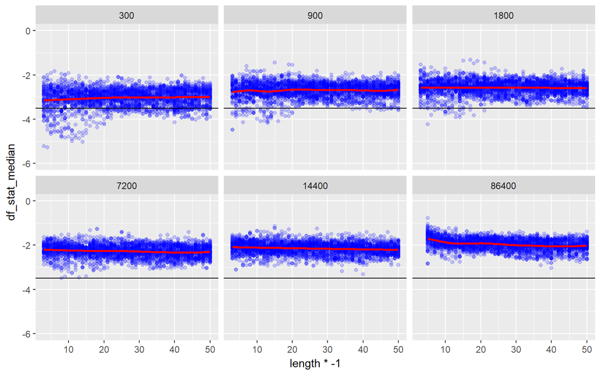

```r
ggplot(results_b, aes(x = length * -1)) +
  geom_point(aes(y = df_stat_median), colour = "blue", alpha = 0.2) +
  geom_hline(yintercept = -3.50) +
  coord_cartesian(ylim = c(-6, 0)) +
  geom_smooth(aes(y = df_stat_median), colour = "red") +
  facet_wrap(~ time_resolution)
```

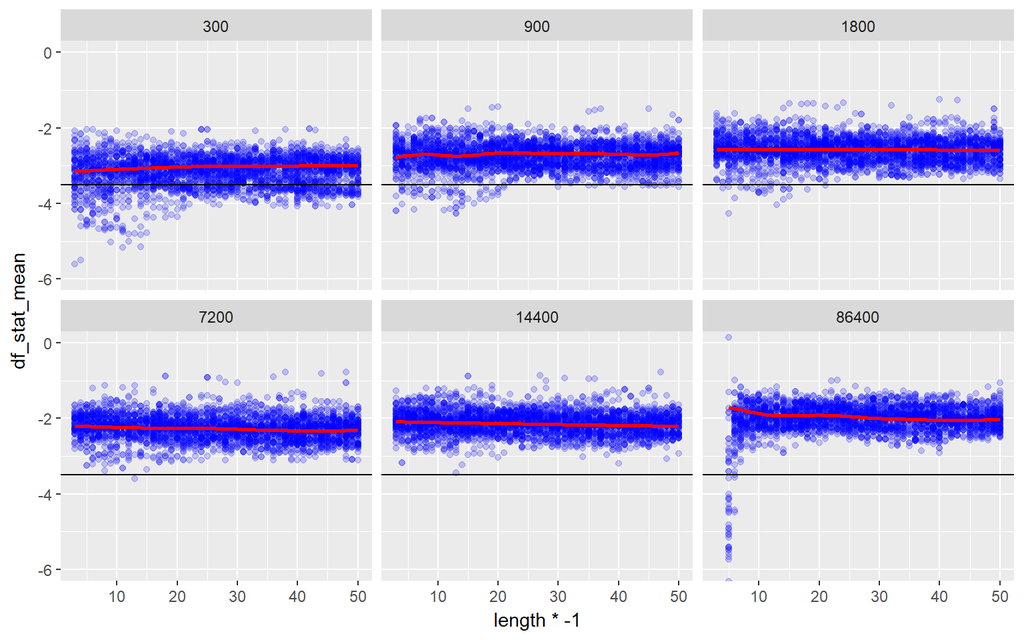

```r
ggplot(results_b, aes(x = length * -1)) +
  geom_point(aes(y = df_stat_mean), colour = "blue", alpha = 0.2) +
  geom_hline(yintercept = -3.50) +
  coord_cartesian(ylim = c(-6, 0)) +
  geom_smooth(aes(y = df_stat_median), colour = "red") +
  facet_wrap(~ time_resolution)
```

Mean and of the mean ADF test statistic and median of the median ADF test statistic by length.

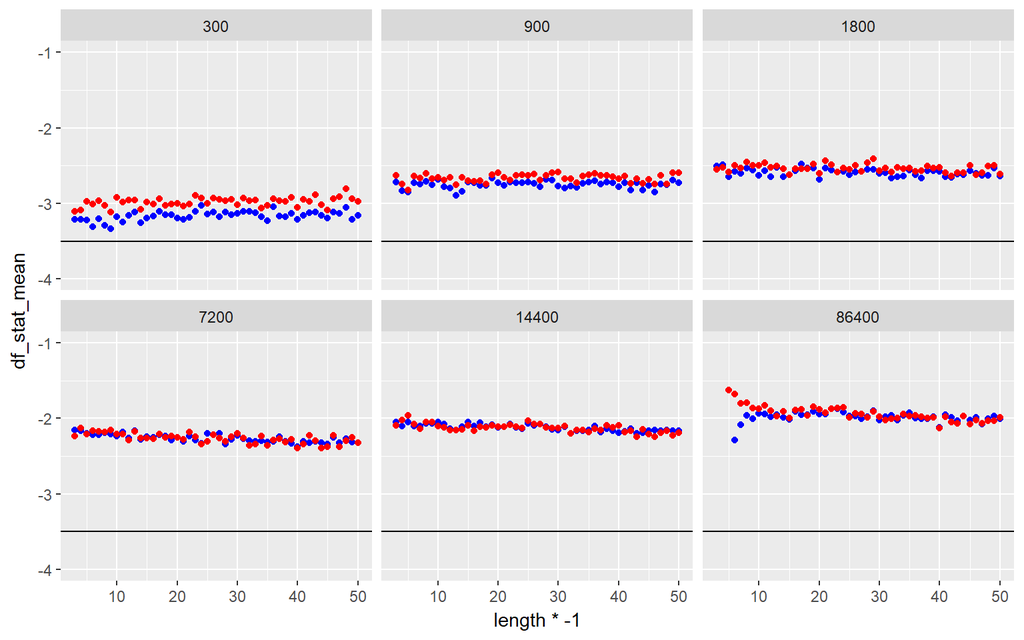

```r
results_b %>%
  group_by(time_resolution, length) %>%
  summarise(df_stat_mean = mean(df_stat_mean),
            df_stat_median = median(df_stat_median)) %>%
  ggplot(aes(x = length * - 1)) +
  geom_point(aes(y = df_stat_mean), colour = "blue") +
  geom_point(aes(y = df_stat_median), colour = "red") +
  geom_hline(yintercept = -3.50) +
  coord_cartesian(ylim = c(-4, -1)) +
  facet_wrap(~ time_resolution)
```